# Data HW_12

Alex Khaykin

2024-04-14

The attached who.csv dataset contains real-world data from 2008. The variables included follow.

Country: name of the country LifeExp: average life expectancy for the country in years InfantSurvival: proportion of those surviving to one year or more Under5Survival: proportion of those surviving to five years or more TBFree: proportion of the population without TB. PropMD: proportion of the population who are MDs PropRN: proportion of the population who are RNs PersExp: mean personal expenditures on healthcare in US dollars at average exchange rate GovtExp: mean government expenditures per capita on healthcare, US dollars at average exchange rate TotExp: sum of personal and government expenditures.

1. Provide a scatterplot of LifeExp~TotExp, and run simple linear regression. Do not transform the variables. Provide and interpret the F statistics, R^2, standard error,and p-values only. Discuss whether the assumptions of simple linear regression met.
2. Raise life expectancy to the 4.6 power (i.e., LifeExp^4.6). Raise total expenditures to the 0.06 power (nearly a log transform, TotExp^.06). Plot LifeExp^4.6 as a function of TotExp^.06, and r re-run the simple regression model using the transformed variables. Provide and interpret the F statistics, R^2, standard error, and p-values. Which model is “better?”
3. Using the results from 3, forecast life expectancy when TotExp^.06 =1.5. Then forecast life expectancy when TotExp^.06=2.5.
4. Build the following multiple regression model and interpret the F Statistics, R^2, standard error, and p-values. How good is the model? LifeExp = b0+b1 x PropMd + b2 x TotExp +b3 x PropMD x TotExp
5. Forecast LifeExp when PropMD=.03 and TotExp = 14. Does this forecast seem realistic? Why or why not?

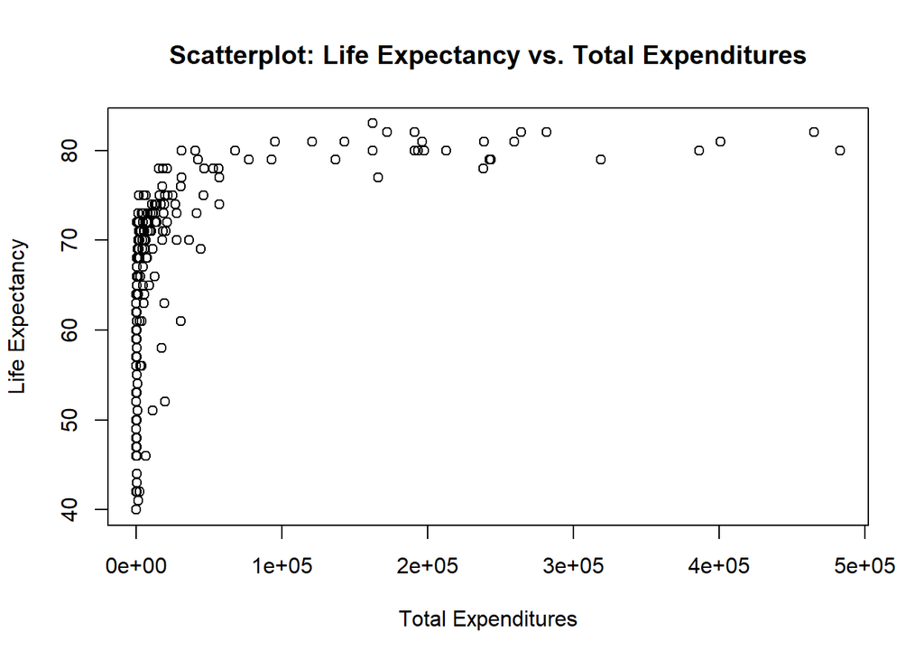

```r
# to load the dataset
who_data <- read.csv("C:\\Users\\akhay\\OneDrive\\Documents\\DATA_SCIENCE\\DATA 605\\Week_12\\who_data.csv")

# to create a scatterplot
plot(who_data$TotExp, who_data$LifeExp, xlab = "Total Expenditures", ylab = "Life Expectancy",
     main = "Scatterplot: Life Expectancy vs. Total Expenditures")
```

```r
# to run simple linear regression
lm_result <- lm(LifeExp ~ TotExp, data = who_data)

# Eto extract relevant statistics
summary(lm_result)$coefficients
```

```
##                 Estimate   Std. Error   t value      Pr(>|t|)
## (Intercept) 6.475337e+01 7.535366e-01 85.932619 7.807071e-153
## TotExp      6.297019e-05 7.794666e-06  8.078626  7.713993e-14
```

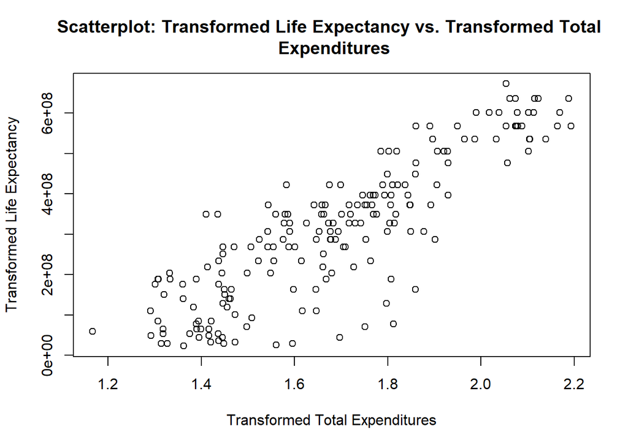

```r
# to transform variables
who_data$LifeExp_transformed <- who_data$LifeExp^4.6
who_data$TotExp_transformed <- who_data$TotExp^0.06

# to create a scatterplot
plot(who_data$TotExp_transformed, who_data$LifeExp_transformed,
     xlab = "Transformed Total Expenditures", ylab = "Transformed Life Expectancy",
     main = "Scatterplot: Transformed Life Expectancy vs. Transformed Total \n Expenditures")
```

```r
# to run regression with new variables
lm_result_transformed <- lm(LifeExp_transformed ~ TotExp_transformed, data = who_data)

# to extract relevant statistics
summary(lm_result_transformed)$coefficients
```

```
##                      Estimate Std. Error   t value     Pr(>|t|)
## (Intercept)        -736527909   46817945 -15.73174 3.911774e-36
## TotExp_transformed  620060216   27518940  22.53213 2.601428e-55
```

```r
# to forecast life expectancy at TotExp_transformed = 1.5
forecast_1.5 <- predict(lm_result_transformed, newdata = data.frame(TotExp_transformed = 1.5))

# to forecast life expectancy at TotExp_transformed = 2.5
forecast_2.5 <- predict(lm_result_transformed, newdata = data.frame(TotExp_transformed = 2.5))
```

```r
# to build multiple regression model
lm_multiple <- lm(LifeExp ~ PropMD + TotExp + PropMD * TotExp, data = who_data)

# to extract relevant statistics
summary(lm_multiple)$coefficients
```

```
##                    Estimate   Std. Error   t value      Pr(>|t|)
## (Intercept)    6.277270e+01 7.956052e-01 78.899309 6.207187e-145
## PropMD         1.497494e+03 2.788169e+02  5.370887  2.320603e-07
## TotExp         7.233324e-05 8.981926e-06  8.053199  9.386290e-14
## PropMD:TotExp -6.025686e-03 1.472357e-03 -4.092543  6.352733e-05
```

Smaller p-values mean more significant relationships. Also, the signs of the coefficients (+/-) indicate the direction of the relationship between the predictor and dependant variables.

```r
# to forecast LifeExp when PropMD = 0.03 and TotExp = 14
forecast_specific <- predict(lm_multiple, newdata = data.frame(PropMD = 0.03, TotExp = 14))
```

```r
summary(forecast_specific)
```

```
##    Min. 1st Qu.  Median    Mean 3rd Qu.    Max.
##   107.7   107.7   107.7   107.7   107.7   107.7
```

# Conclusion

The forecasted life expectancy of 108 does not seam realistic. But certainly possible.